# Quantification

A missing precursor usually means it was too faint to detect, not that it was absent at random. limpa turns that into a model in two steps. `dpc()` fits one detection probability curve for the whole experiment: the chance a precursor is detected, given how abundant it is. `dpcQuant()` then gives every protein a value and a standard error in every biopsy, using its observed precursors and, through the curve, what its missing ones imply. Nothing is filled in as if measured; a value resting on few detections carries a wide standard error, and later fits weight it less.

After quantification this step builds the blood index, removes contaminant proteins and keeps proteins detected often enough to compare.

## Packages

```r
library(here)
library(limma)
library(limpa)
library(dplyr)
library(ggplot2)
source(here("00_Setup", "Shared_functions", "workbooks.R"))
step <- here("01_Processing", "02_Quantification")
inputs <- c(
  precursors = "01_Processing/01_Precursors/c_data/precursors.rds",
  contaminants = "01_Processing/02_Quantification/references/contaminants.csv"
)
paths <- vapply(inputs, here, character(1))
stopifnot(file.exists(paths))
```

## Input

The precursor matrix from `01_Precursors`: log2 intensities, `NA` where undetected, one column per biopsy.

```r
y <- readRDS(paths[["precursors"]])
c(precursors = nrow(y), proteins = n_distinct(y$genes$Protein.Group), biopsies = ncol(y))
```

```
precursors   proteins   biopsies
     22342       2401         48
```

## Detection probability curve

The curve is logistic: P(detected | log2 intensity y) = plogis(β0 + β1 y). The slope β1 says how strongly detection depends on abundance; 0 would mean values go missing at random. limpa’s authors report slopes of about 0.7 to 1 in real data. The curve is fitted on every precursor, contaminants included, because it describes the instrument’s detection of any precursor.

```r
dpcest <- dpc(y)
dpcest$dpc
```

```
     beta0      beta1
-11.948040   0.679028
```

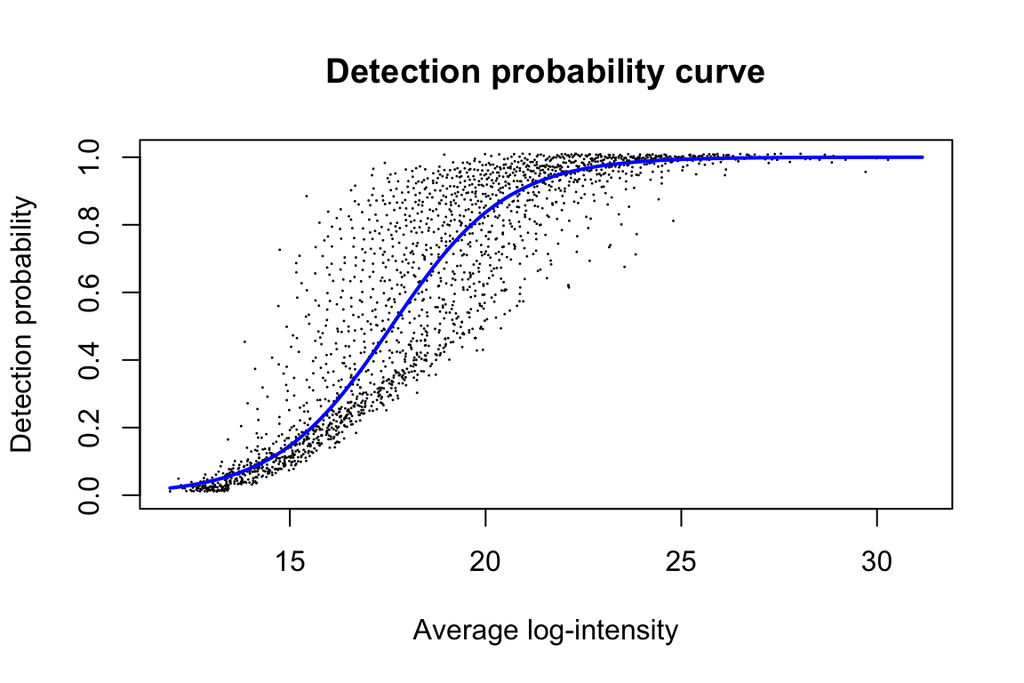

Figure 1: Detection probability against log2 intensity (limpa’s plotDPC).

```r
plotDPC(dpcest)
```

## Quantify proteins

`dpcQuant()` fits each protein’s precursors together (protein level plus a fixed offset per precursor), with the missing ones entering through the curve and a prior estimated from all proteins. It returns complete log2 values in `E`, a standard error per value in `other$standard.error`, and per protein the precursor count (`NPrec`) and the share of values observed (`PropObs`).

```r
proteins <- dpcQuant(y, "Protein.Group", dpc = dpcest)
c(proteins = nrow(proteins), biopsies = ncol(proteins), missing = sum(is.na(proteins$E)))
```

```
proteins biopsies  missing
    2401       48        0
```

How much each protein rests on: precursors per protein and the share of its values observed.

```r
proteins$genes |>
  as_tibble() |>
  summarise(
    proteins = n(), one_precursor = sum(NPrec == 1), median_precursors = median(NPrec),
    median_observed = round(median(PropObs), 2), observed_under_half = sum(PropObs < 0.5)
  )
```

```
# A tibble: 1 × 5
  proteins one_precursor median_precursors median_observed observed_under_half
     <int>         <int>             <dbl>           <dbl>               <int>
1     2401           390                 4            0.54                1078
```

```r
quantile(proteins$other$standard.error, c(0, 0.25, 0.5, 0.75, 1))
```

```
       0%       25%       50%       75%      100%
0.0224522 0.3267140 0.5056006 0.7440418 1.6458513
```

Standard errors grow as fewer values are observed:

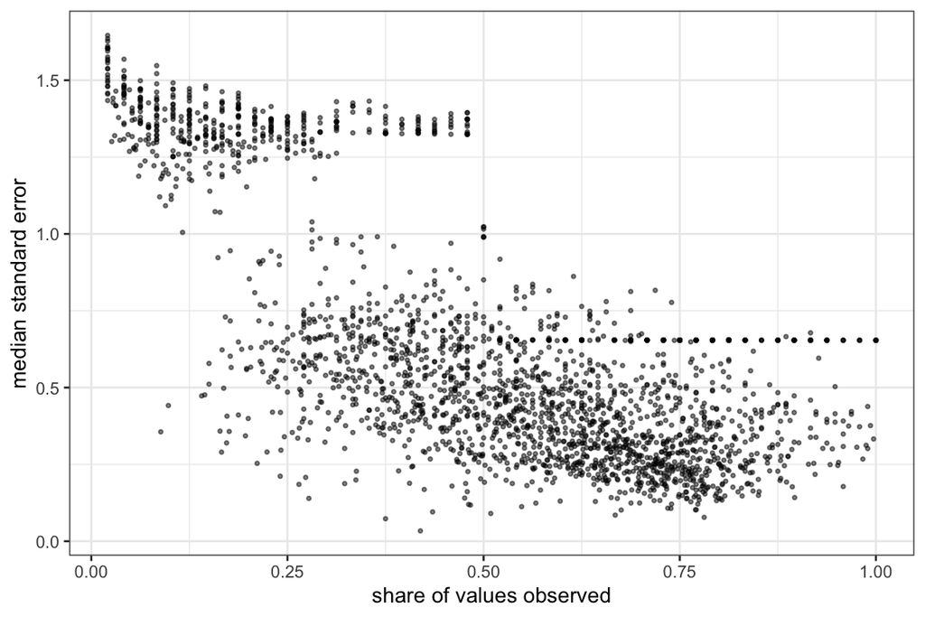

Figure 2: Median standard error per protein against the share of its values observed.

```r
tibble(
  observed = proteins$genes$PropObs,
  se = apply(proteins$other$standard.error, 1, median)
) |>
  ggplot(aes(observed, se)) +
  geom_point(size = 0.6, alpha = 0.5) +
  labs(x = "share of values observed", y = "median standard error") +
  theme_bw(base_size = 10)
```

## Samples

`plotMDSUsingSEs()` (limpa) places biopsies by their protein values, like limma’s `plotMDS`, but takes the standard errors into account. Colour is time point, label the biopsy.

```
[1] 0.318 0.141
```

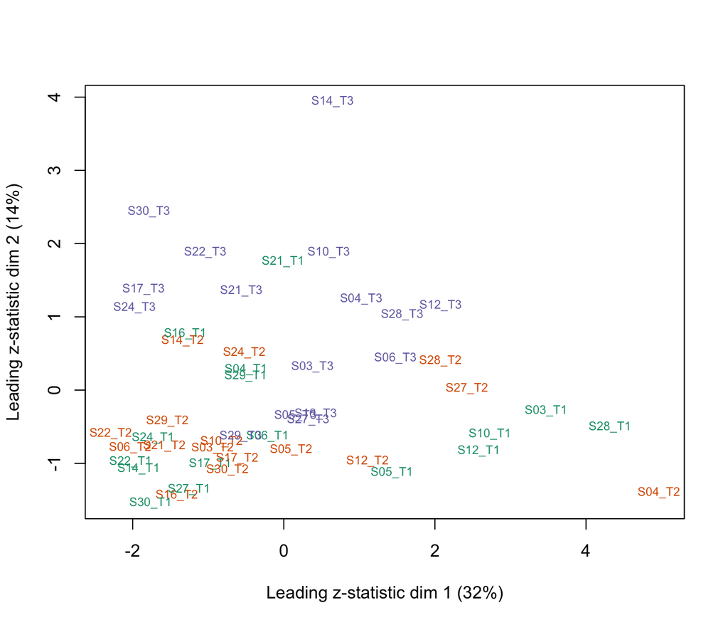

Figure 3: Multidimensional scaling of the biopsies (limpa’s plotMDSUsingSEs).

```r
tp_colour <- c(T1 = "#1B9E77", T2 = "#D95F02", T3 = "#7570B3")
mds <- plotMDSUsingSEs(
  proteins,
  labels = colnames(proteins), col = tp_colour[proteins$targets$timepoint], cex = 0.7
)
round(mds$var.explained[1:2], 3)
```

## Blood index

Blood in a biopsy dilutes the muscle proteins. The index is each biopsy’s mean log2 HBB and HBA1, taken from limpa’s complete values, centred on the mean biopsy. Comparisons carry it as a covariate.

```r
blood_rows <- grepl("(^|;)(HBB|HBA1)(;|$)", proteins$genes$Genes)
proteins$genes[blood_rows, c("Genes", "NPrec", "PropObs")]
```

```
       Genes NPrec   PropObs
P68871   HBB    38 0.6524123
P69905  HBA1    27 0.7368827
```

```r
stopifnot(sum(blood_rows) >= 2)
blood <- colMeans(proteins$E[blood_rows, , drop = FALSE])
proteins$targets$blood <- unname(blood - mean(blood))
blood_index <- proteins$targets |>
  as_tibble() |>
  select(sample_id, subject, group, timepoint, blood)
summary(blood_index$blood)
```

```
   Min. 1st Qu.  Median    Mean 3rd Qu.    Max.
-2.1601 -0.6658 -0.2446  0.0000  0.5995  2.6823
```

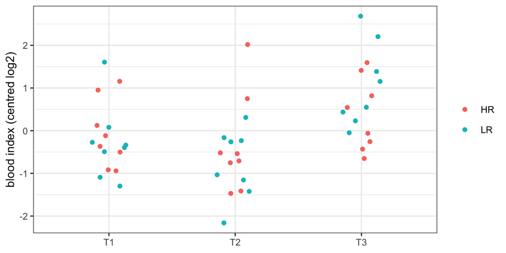

Figure 4: Blood index per biopsy by time point and group.

```r
ggplot(blood_index, aes(timepoint, blood, colour = group)) +
  geom_point(position = position_jitter(width = 0.15, seed = 1)) +
  labs(x = NULL, y = "blood index (centred log2)", colour = NULL) +
  theme_bw(base_size = 10)
```

## Contaminants

`references/contaminants.csv` holds the 222 contaminant proteins the earlier protein-level pipeline resolved (plasma, immunoglobulin, erythrocyte, keratin, complement, globin, leukocyte; see `references/README.md`). They are removed now, after quantification: each protein is quantified from its own precursors, so removing them afterwards leaves every other protein’s values unchanged apart from the shared prior.

```r
contaminants <- readr::read_csv(paths[["contaminants"]], show_col_types = FALSE)
removed <- contaminants |>
  filter(uniprot_id %in% rownames(proteins)) |>
  arrange(class, gene)
count(removed, class)
```

```
# A tibble: 7 × 2
  class              n
  <chr>          <int>
1 complement        12
2 erythrocyte       19
3 globin             7
4 immunoglobulin    41
5 keratin           18
6 leukocyte          5
7 plasma           120
```

```r
c(on_list = nrow(contaminants), present = nrow(removed))
```

```
on_list present
    222     222
```

```r
proteins <- proteins[!rownames(proteins) %in% contaminants$uniprot_id, ]
nrow(proteins)
```

```
[1] 2179
```

Proteins not on the list cannot be removed by it. Remaining keratin, immunoglobulin and haemoglobin genes, printed for review and kept:

```r
review <- proteins$genes |>
  as_tibble(rownames = "uniprot_id") |>
  filter(grepl("(^|;)(KRT|IG[HKL]|HB[ABDGQ])", Genes)) |>
  select(uniprot_id, gene = Genes, n_precursors = NPrec, prop_observed = PropObs)
review
```

```
# A tibble: 1 × 4
  uniprot_id gene  n_precursors prop_observed
  <chr>      <chr>        <dbl>         <dbl>
1 P08727     KRT19            3         0.208
```

## Detection filter

`filterByDetection()` (limpa) keeps proteins with at least one observed precursor in at least `n.samples` biopsies. Its help page suggests the smallest group size for a small study; each group-by-time cell holds 8 biopsies, so a kept protein was detected in at least one cell’s worth of biopsies (decisions log, 2026-10-15). It runs after quantification, as limpa intends: the curve and the prior use every precursor.

```r
detected <- filterByDetection(proteins, n.samples = 8)
table(kept = detected)
```

```
kept
FALSE  TRUE
  120  2059
```

```r
dropped <- proteins$genes[!detected, ] |>
  as_tibble(rownames = "uniprot_id") |>
  select(uniprot_id, gene = Genes, n_precursors = NPrec, prop_observed = PropObs)
proteins <- proteins[detected, ]
c(proteins = nrow(proteins), one_precursor = sum(proteins$genes$NPrec == 1))
```

```
     proteins one_precursor
         2059           276
```

## Protein values per biopsy

The same check as for precursors, now on limpa’s complete protein values: one curve per biopsy, which should overlap.

```
   Min. 1st Qu.  Median    Mean 3rd Qu.    Max.
  16.33   17.65   17.81   17.75   17.89   18.19
```

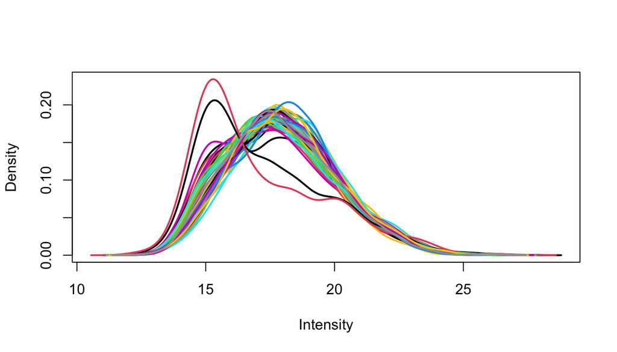

Figure 5: log2 protein values per biopsy (limma’s plotDensities).

```r
plotDensities(proteins, legend = FALSE, main = "")
round(summary(apply(proteins$E, 2, median)), 2)
```

## Validation

```r
stopifnot(
  !anyNA(proteins$E), all(proteins$other$standard.error > 0),
  identical(colnames(proteins), proteins$targets$sample_id),
  !any(rownames(proteins) %in% contaminants$uniprot_id), !anyNA(proteins$targets$blood)
)
```

## Summary

2059 proteins in 48 biopsies, after removing 222 contaminants and 120 proteins detected in fewer than 8 biopsies. The detection curve’s slope is 0.68; 276 kept proteins rest on a single precursor.

## Save

`quantification.rds` is limpa’s `EList`: `E`, `other$standard.error`, `genes` and `targets` with the blood index. `dpcDE()` in the comparisons reads it directly.

```r
out <- file.path(step, "c_data")
dir.create(out, showWarnings = FALSE)
saveRDS(proteins, file.path(out, "quantification.rds"))
write_workbook(
  list(
    dpc = tibble(term = names(dpcest$dpc), estimate = unname(dpcest$dpc)),
    proteins = as_tibble(proteins$genes, rownames = "uniprot_id") |>
      select(
        uniprot_id, protein_name = Protein.Names, gene = Genes, n_precursors = NPrec,
        prop_observed = PropObs
      ),
    blood_index = blood_index,
    contaminants_removed = removed,
    contaminant_review = review,
    detection_dropped = dropped
  ),
  c(
    "Detection probability curve: intercept (beta0) and slope (beta1).",
    "Every protein kept: names, precursor count and share of values observed.",
    "Blood index per biopsy (centred mean log2 HBB and HBA1).",
    "Contaminant proteins removed, with class and reason.",
    "Keratin, immunoglobulin and haemoglobin genes not on the list, kept for review.",
    "Proteins detected in fewer than 8 biopsies, dropped by filterByDetection()."
  ),
  file.path(out, "quantification.xlsx"), inputs, paths
)
```